# Udacity - Data Analysis Nanodegree - Project 1

#### Analysis of the NYC Subway dataset to see if ridership is significantly different at times when it is raining vs not raining

## Section 0 - References

Please see file "da_nano_project1_refs.pdf" included in the submissions pack.

## Section 1 - Statistical Test

The NYC Subway data is presented as a file of observations with the following variables:

- UNIT - The station entry unit
- DATEn - Date of observation
- TIMEn - Time of observation
- Hour - A numeric from 0-23 indicating the hour of day
- DESCn - The type of entry REGULAR, etc
- ENTRIESn_hourly - Number of entries since previous REGULAR observation
- EXITSn_hourly - Number of exits since previous REGULAR observation
- maxpressurei - Maximum pressure for that day (inches Hg)
- maxdewpti - Maximum dew point for that day (Deg F)
- mindewpti - Minimum dew point for that day (Deg F)
- minpressurei - Minimum pressure for that day (inches Hg)
- meandewpti - Average dew point for the day
- meanpressurei - Average pressure for the day
- fog - 0 indicating no fog and 1 fog
- rain - 0 indicating no rain and 1 rain
- meanwindspdi - Average windspeed in mph for that day
- mintempi - Minimum temperature for that day (Deg F)
- meantempi - Average temperature for that day (Deg F)
- maxtempi - Maximum temperature for that day (Deg F)
- precipi - Precipitation in inches at that time
- thunder - 0 for no thunder activity and 1 for thunder

```python
#Imports
import pandas as pd
import numpy as np
import matplotlib.pyplot as plt
import statsmodels.api as sm
import scipy
import scipy.stats
from ggplot import *
%matplotlib inline
```

We load the data into a pandas dataframe for manipulation, and separate into a sample with rain and one without rain. Calculating the mean of both samples returns a higher average subway ridership for days that are raining than not raining.

```python
# Load the enhanced dataset into pandas
wdf = pd.read_csv('turnstile_data_master_with_weather.csv')
#wdf = pd.read_csv('turnstile_weather_v2.csv')

# Seperate observations with rain from those without rain
rain_days = wdf['ENTRIESn_hourly'][(wdf['rain']==1)]
no_rain_days = wdf['ENTRIESn_hourly'][(wdf['rain']==0)]
```

### Section 1.1 and Section 1.2

**Which statistical test did you use to analyze the NYC subway data? Did you use a one-tail or a two-tail P value? What is the null hypothesis? What is your p-critical value?**

**Why is this statistical test applicable to the dataset? In particular, consider the assumptions that the test is making about the distribution of ridership in the two samples.**

In order to compare means via Welch's t-test we need to determine whether the samples appear to be drawn from a normally distributed population.

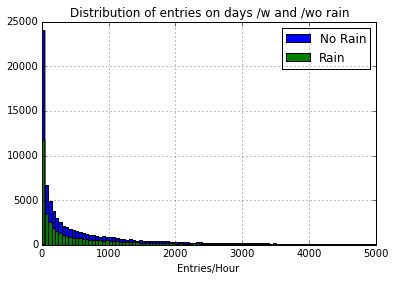

```python
#Show the comparative distribution of the two samples

plt.figure()
plt.title("Distribution of entries on days /w and /wo rain")
plt.xlabel('Entries/Hour')
no_rain_days.hist(bins=100,range=(0,5000),label="No Rain")
rain_days.hist(bins=100,range=(0,5000),label="Rain")
plt.legend()
plt.show()
```

The above histogram range is limited to 5000 Entries/hr to better indicate the shape

Visually these two sample distributions do not appear normally distributed.

This can be confirmed by performing a Shapiro-Wilk test on each with a the null hypothesis stipulating that the two populations are indeed normally distributed.

```python
sp_wr = scipy.stats.shapiro(rain_days)
sp_wor = scipy.stats.shapiro(no_rain_days)
print "Shapiro-Wilk test p-values for normality - Rain Days: {0:7.5f} - Non-Rain Days: {1:7.5f}".format(sp_wr[1],sp_wor[1])
```

```
Shapiro-Wilk test p-values for normality - Rain Days: 0.00000 - Non-Rain Days: 0.00000
```

As the p-value returned from is extremely small, we reject the null hypothesis and conclude that neither sample appears to be from a Normally Distibuted population.

This makes Welch's t-test is inappropriate, and we perform a non-parametric **Mann-Whitney U test** instead.

Because the models return p-values for a 1-tailed test we are required to double the result for a 2-tailed test

### Section 1.3 and Section 1.4

**What results did you get from this statistical test? These should include the following numerical values: p-values, as well as the means for each of the two samples under test.**

**What is the significance and interpretation of these results?**

```python
U,p = scipy.stats.mannwhitneyu(rain_days,no_rain_days)
rain_days_mean = np.mean(rain_days)
no_rain_days_mean = np.mean(no_rain_days)

print "Mann-Whitney U-test - score: {0}  -  p-value: {1} - 2-tail p-value: {2}".format(U,p,p*2)
print "Sample Means - No Rain Days: {0:7.3f} - Rain Days: {1:7.3f}".format(no_rain_days_mean,rain_days_mean)
```

```
Mann-Whitney U-test - score: 1924409167.0  -  p-value: 0.0249999127935 - 2-tail p-value: 0.049999825587
Sample Means - No Rain Days: 1090.279 - Rain Days: 1105.446
```

With an α = 0.05 and a 2-tail p-value of 0.049999 being in the critical region, we find the difference between the two populations statistically significant and reject the null that they are identical. With the difference in the mean values of ridership it would suggest that more people ride the subway on rainy days

## Section 2 - Linear Regression

### Section 2.1

**What approach did you use to compute the coefficients theta and produce prediction for ENTRIESn_hourly in your regression model**

We have opted to use the Ordinary Least Squares model from Statsmodels to perform the linear regression.

```python
obs = np.array(wdf["ENTRIESn_hourly"])
```

```python
import time
def day_of_week(date,return_string = False):
    '''
    Return the day of the week as in integer with Monday=0 and Sunday=6
    '''
    timeStruct = time.strptime(date,"%Y-%m-%d")
    #dateStr = time.strftime("%Y-%m-%d",timeStruct)
    #date_formatted = dateStr
    if return_string:
        return ["0-Monday","1-Tuesday","2-Wednesday","3-Thursday","4-Friday","5-Saturday","6-Sunday"][timeStruct.tm_wday]
    else:
        return timeStruct.tm_wday
```

```python
def normalize_features(df):
    """
    Normalize the features in the data set.
    """
    mu = df.mean()
    sigma = df.std()

    if (sigma == 0).any():
        raise Exception("One or more features had the same value for all samples, and thus could " + \
                         "not be normalized. Please do not include features with only a single value " + \
                         "in your model.")
    df_normalized = (df - df.mean()) / df.std()

    return df_normalized, mu, sigma
```

```python
def predictions_OLS(dataframe):
    values = dataframe['ENTRIESn_hourly']
    m = len(values)

    # Add weekday number and is_weekend boolean features
    dataframe["day_of_week"] = dataframe["DATEn"].map(lambda x: day_of_week(x))
    dataframe["is_weekend"] = dataframe["day_of_week"].map(lambda x: 1 if (x>=5) else 0)

    # Select Features (try different features!)
    features = dataframe[['rain', 'Hour', 'fog', 'mintempi', 'is_weekend']]

    # Add UNIT to features using dummy variables
    dummy_units = pd.get_dummies(dataframe['UNIT'], prefix='unit')
    features = features.join(dummy_units)

    features, mu, sigma = normalize_features(features)
    features['ones'] = np.ones(m) # Add a column of 1s (y intercept)

    values_array = np.array(values)
    model = sm.regression.linear_model.OLS(values_array,features,missing='none',hasconst=True)

    return model
```

### Section 2.2

**What features (input variables) did you use in your model? Did you use any dummy variables as part of your features?**

Before performing regression we modified the dataset to add two new features:

- **day_of_week**: This is set to 0 for a Monday through to 6 for a Sunday and derived from **DATEn**
- **is_weekend**: This is a boolean set to 0 if **day_of_week** in (0,1,2,3,4) and 1 if in (5,6)

We also create dummy variables for each value of **UNIT**, which has the disadvantage of introducing numerous variables to the regression model, but dramatically improves the results.

The final selection of features (excluding dummies) was : **'rain', 'Hour', 'fog', 'mintempi', 'is_weekend'**

### Section 2.3

**Why did you select these features in your model? We are looking for specific reasons that lead you to believe that the selected features will contribute to the predictive power of your model.**

The rationale behind the selection was first to focus on those variables we felt could consciously influence a person's decision as to whether to take the subway train or not. These would be conditions that should be immediately apparent to the rider at the time of making the decision which would exclude those like atmospheric pressure and possibly dew point.

### Section 2.4

**What are the coefficients (or weights) of the non-dummy features in your linear regression model?**

```python
OLSModel = predictions_OLS(wdf).fit()
preds_OLS = OLSModel.predict()
print OLSModel.params[0:5]
```

```
rain          -42.361717
Hour          464.011168
fog            28.809864
mintempi      -44.571623
is_weekend   -239.409783
dtype: float64
```

### Section 2.5

**What is your model’s R2 (coefficients of determination) value?**

```python
def compute_r_squared(data, predictions):
    # Write a function that, given two input numpy arrays, 'data', and 'predictions,'
    # returns the coefficient of determination, R^2, for the model that produced
    # predictions.
    #
    # Numpy has a couple of functions -- np.mean() and np.sum() --
    # that you might find useful, but you don't have to use them.

    # YOUR CODE GOES HERE
    data_mean = np.mean(data)
    obs_exp_diff = data - predictions
    obs_mean_diff = data - data_mean
    r_squared = 1 - (np.dot(obs_exp_diff,obs_exp_diff)/np.dot(obs_mean_diff,obs_mean_diff))

    # Could also use numpy.square and then numpy.sum() to square the array but retain its size
    # symbol to square values of the array appears to be **2

    return r_squared
```

```python
print "R^2 - coefficient of determination: {0}".format(compute_r_squared(obs,preds_OLS))
```

```
R^2 - coefficient of determination: 0.468675166385
```

### Section 2.6

**What does this R2 value mean for the goodness of fit for your regression model? Do you think this linear model to predict ridership is appropriate for this dataset, given this R2 value?**

R<sup>2</sup> has a range of 0.0 to 1.0 with 0 indicating that the model does not fit the data at all and 1.0 indicating that it fits it perfectly. Give a R<sup>2</sup> value of 0.47 indicates that the model is not particularly good and there may well be undicovered relationships lying between the variables or indeed the true model may not be linear.

## Section 3 - Visualization

### Section 3.1

**One visualization should contain two histograms: one of ENTRIESn_hourly for rainy days and one of ENTRIESn_hourly for non-rainy days**

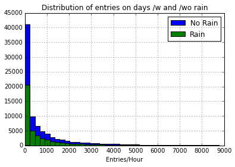

```python
plt.figure()
plt.title("Distribution of entries on days /w and /wo rain")
plt.xlabel('Entries/Hour')
no_rain_days.hist(bins=40,range=(0,9000),label="No Rain")
rain_days.hist(bins=40,range=(0,9000),label="Rain")
plt.legend()
plt.show()
```

### Section 3.2

**One visualization can be more freeform**

To further explore the distribution of Rain vs Non-Rain days we can view the distributions on broken down by the day of the week and another by the hour of the day.

```python
def plot_weather_data(turnstile_weather):
    '''
    You are passed in a dataframe called turnstile_weather.
    Use turnstile_weather along with ggplot to make a data visualization
    focused on the MTA and weather data we used in assignment #3.
    You should feel free to implement something that we discussed in class
    (e.g., scatterplots, line plots, or histograms) or attempt to implement
    something more advanced if you'd like.

    Here are some suggestions for things to investigate and illustrate:
     * Ridership by time of day or day of week
     * How ridership varies based on Subway station (UNIT)
     * Which stations have more exits or entries at different times of day
       (You can use UNIT as a proxy for subway station.)

    If you'd like to learn more about ggplot and its capabilities, take
    a look at the documentation at:
    https://pypi.python.org/pypi/ggplot/

    You can check out:
    https://www.dropbox.com/s/meyki2wl9xfa7yk/turnstile_data_master_with_weather.csv

    To see all the columns and data points included in the turnstile_weather
    dataframe.

    However, due to the limitation of our Amazon EC2 server, we are giving you a random
    subset, about 1/3 of the actual data in the turnstile_weather dataframe.
    '''
    turnstile_weather.is_copy = False
    turnstile_weather["day_of_week"] = turnstile_weather["DATEn"].map(lambda x: day_of_week(x,True))
    turnstile_weather["is_weekend"] = turnstile_weather["day_of_week"].map(lambda x: 1 if (x>=5) else 0)

    riders_per_day = turnstile_weather[["day_of_week","ENTRIESn_hourly","rain"]]



    plot = plot = ggplot(aes(x="ENTRIESn_hourly", color="rain"),data=riders_per_day) + facet_wrap("day_of_week")+geom_density() + \
         ggtitle('Ridership/day') + xlab('Entries/hr') + ylab('density') +xlim(0,1500)
    return plot
```

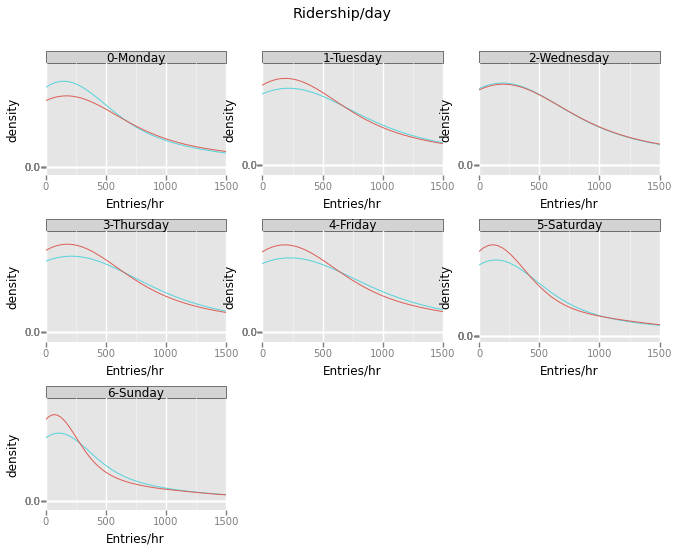

```python
plot_weather_data(wdf)
```

Due to GGPLOT bug, legends are not available but the blue line is with rain, and the red line without As can be seen from the chart above, as the number of entries per hour increases the frequency of with rain occurences starts to exceed the without rain values

```python
def plot_weather_data2(turnstile_weather):
    '''
    You are passed in a dataframe called turnstile_weather.
    Use turnstile_weather along with ggplot to make a data visualization
    focused on the MTA and weather data we used in assignment #3.
    You should feel free to implement something that we discussed in class
    (e.g., scatterplots, line plots, or histograms) or attempt to implement
    something more advanced if you'd like.

    Here are some suggestions for things to investigate and illustrate:
     * Ridership by time of day or day of week
     * How ridership varies based on Subway station (UNIT)
     * Which stations have more exits or entries at different times of day
       (You can use UNIT as a proxy for subway station.)

    If you'd like to learn more about ggplot and its capabilities, take
    a look at the documentation at:
    https://pypi.python.org/pypi/ggplot/

    You can check out:
    https://www.dropbox.com/s/meyki2wl9xfa7yk/turnstile_data_master_with_weather.csv

    To see all the columns and data points included in the turnstile_weather
    dataframe.

    However, due to the limitation of our Amazon EC2 server, we are giving you a random
    subset, about 1/3 of the actual data in the turnstile_weather dataframe.
    '''
    turnstile_weather.is_copy = False

    riders_per_hour = turnstile_weather[["Hour","ENTRIESn_hourly","rain"]]



    plot = plot = ggplot(aes(x="Hour",y="ENTRIESn_hourly",color="rain"),data=riders_per_hour) + geom_point() + \
         ggtitle('Entries per hour of the day') + xlab('Hour of Day') + ylab('Entries/hr') + xlim(-1,24)
    return plot
```

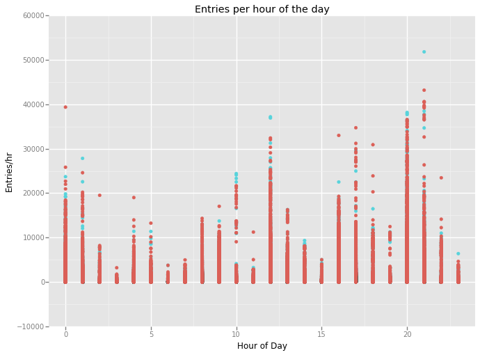

```python
plot_weather_data2(wdf)
```

This scatter plot shows the various entries per hour as broken down per hour of the day. The points in blue indicate those on days with Rain and red points are without.

## Section 4 - Conclusion

### Section 4.1

**From your analysis and interpretation of the data, do more people ride the NYC subway when it is raining or when it is not raining?**

### Section 4.2

**What analyses lead you to this conclusion? You should use results from both your statistical tests and your linear regression to support your analysis.**

## Section 5 - Reflections

### Section 5.1

**Please discuss potential shortcomings of the methods of your analysis, including: Dataset,Analysis, such as the linear regression model or statistical test.**

The most noteable shortcoming in the dataset, is that it only includes the information for one calendar month and not a full year. Give the changes that weather patterns and holidays may have as we move from season to season, a more accurate model would require a full years data at the very least.

We felt that the R<sup>2</sup> coefficient was not high enough to suggest that the model was particularly good, and the potentially more emphasis should have been placed on feature selection and possibly more categorical classification of data